# ¿Existe diferencia de precios entre oferentes Superhost y oferentes corrientes en Airbnb? Estudio acotado a Amsterdam

### Autor: José Arriagada H.

### Fecha última actualización: 2023-03-30

# Introducción

Este es un sencillo proyecto en el que, a partir de una base de datos de precios de Airbnb de diferentes ciudades en Europa, me propongo averiguar si existe una diferencia significativa en los precios ofrecidos por los oferentes que son Superhost versus quienes no lo son.

La hipóstesis es que los usuarios que son Superhost podrían cobrar mayores precios gracias a la confianza y prestigio que les otorga el estatus de Superhost.

El estudio está acotado para la ciudad de Amsterdam, pero el código está escrito de tal forma que fácilmente puede reutilizarse para analizar otras ciudades.

Los datos corresponden al material complementario del estudio "Determinants of Airbnb prices in European cities: A spatial econometrics approach" descargados desde Kaggle.

> Gyódi, Kristóf, & Nawaro, Łukasz. (2021). Determinants of Airbnb prices in European cities: A spatial econometrics approach (Supplementary Material) [Data set]. Zenodo. https://doi.org/10.5281/zenodo.4446043

# 1. Importación y ajuste del DataSet a las necesidades del proyecto

### 1.1 Importación de Pandas

```python
import pandas as pd
```

### 1.2 Creación de un solo DataFrame

Los datos vienen separados por días de semana y días de fin de semana (con las mismas variables). Por ello primero debemos concatenarlos.

```python
# Importación de ambos CSVs por separado
amsterdam_weekdays = pd.read_csv('datasets/amsterdam_weekdays.csv')
amsterdam_weekends = pd.read_csv('datasets/amsterdam_weekends.csv')

# Creación de una variable adicional para identificar cada dataset (En caso de necesitarlo a futuro)
amsterdam_weekdays['day'] = 'weekday'
amsterdam_weekends['day'] = 'weekend'

# Concatenación de ambos Datasets
amsterdam = pd.concat([amsterdam_weekdays, amsterdam_weekends])
```

### 1.3 Limpieza de información innecesaria del DataFrame

```python
# Cada Dataframe anterior tenía su propio index, por lo que es necesario reiniciarlo para evitar confusiones
amsterdam.reset_index(inplace=True, drop=True)

# Selección de solo las variables a ser usadas: Precios (RealSum) y estatus de superhost (host_is_superhost)
amsterdam_superhost = amsterdam[['realSum', 'host_is_superhost']]

# Comprobación de que el DataFrame está en buenas condiciones
amsterdam_superhost.info()
amsterdam_superhost.head(5)
```

```
<class 'pandas.core.frame.DataFrame'>
RangeIndex: 2080 entries, 0 to 2079
Data columns (total 2 columns):
 #   Column             Non-Null Count  Dtype
---  ------             --------------  -----
 0   realSum            2080 non-null   float64
 1   host_is_superhost  2080 non-null   bool
dtypes: bool(1), float64(1)
memory usage: 18.4 KB
```

|  | realSum | host_is_superhost |
| --- | --- | --- |
| 0 | 194.033698 | False |
| 1 | 344.245776 | False |
| 2 | 264.101422 | False |
| 3 | 433.529398 | False |
| 4 | 485.552926 | True |

# 2. Exploración gráfica de los datos

Se crean gráficos de caja y histogramas para explorar la distribución de los datos

### 2.1 Importación de Matplotlib y Seaborn

```python
import matplotlib.pyplot as plt
import seaborn as sns
```

### 2.2 Creación de histograma de Precios (EUR) para Amsterdam

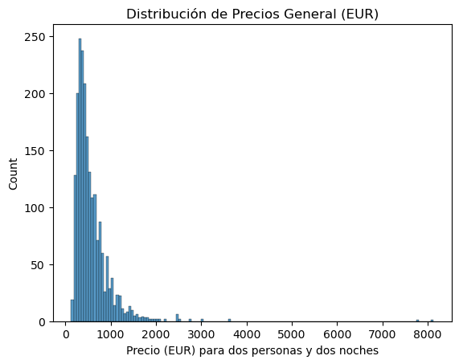

```python
# Histograma en Seaborn
sns.histplot(data=amsterdam_superhost, x='realSum')

# Etiquetas
plt.title('Distribución de Precios General (EUR)')
plt.xlabel('Precio (EUR) para dos personas y dos noches')
plt.ylabel('Count')

# Mostrar el gráfico
plt.show()
```

### 2.3 Creación de histograma de Precios (EUR) para Amsterdam dependiendo si el oferente es Super Host

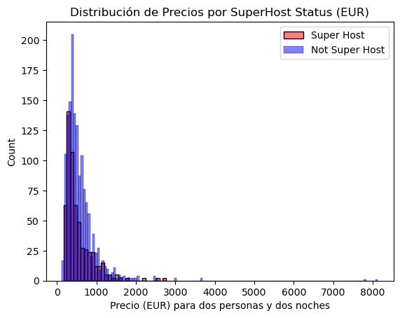

```python
# Primero se crean dos DataFrames, uno para cuando el oferente es SuperHost y otro para cuando no
superhost_yes = amsterdam_superhost[amsterdam_superhost['host_is_superhost'] == True]
superhost_no = amsterdam_superhost[amsterdam_superhost['host_is_superhost'] == False]

# Luego se crean dos histogramas, uno para cada DataFrame recién creado (SuperHost=rojo, no SuperHost=azul)
sns.histplot(data=superhost_yes, x='realSum', kde=False, color='red', alpha=0.5)
sns.histplot(data=superhost_no, x='realSum', kde=False, color='blue', alpha=0.5)

# Se agregan leyendas
plt.legend(labels=['Super Host', 'Not Super Host'])

# Etiquetas
plt.title('Distribución de Precios por SuperHost Status (EUR)')
plt.xlabel('Precio (EUR) para dos personas y dos noches')
plt.ylabel('Count')

# Mostrar el gŕafico
plt.show()
```

### 3.4 Creación de diagrama de caja de Precios (EUR) separados por estatus de SuperHost

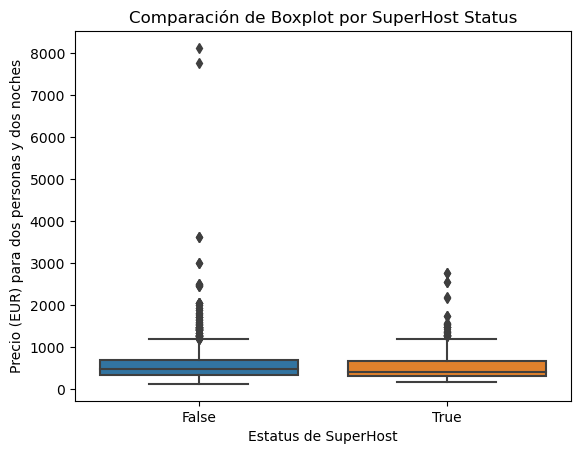

```python
# Creación de BoxPlot por superhost
sns.boxplot(data=amsterdam_superhost, x='host_is_superhost', y='realSum')

# Etiquetas
plt.title('Comparación de Boxplot por SuperHost Status')
plt.xlabel('Estatus de SuperHost')
plt.ylabel('Precio (EUR) para dos personas y dos noches')

# Mostrar el gráfico
plt.show()
```

# 3. Eliminación de valores extremos

En los gráficos anteriores se puede observar una fuerte presencia de valores extremos que hacen que la distribución esté sesgada a la derecha. Se debe tratar ese problema antes de continuar.

Una forma típica de eliminar valores extremos es usar 1.5 veces el rango intercuartil (IQR) que es la diferencia entre el cuartil 3 y el cuartil 1 de nuestros datos como medida estándar.

Así, se conservaran todos los datos que estén bajo las 1.5 veces IQR al cuartil 3 y que estén por encima de 1.5 veces IQR del cuartil 1 según la fórmula:

> datos >= Q1 - 1.5 * IQR

> datos <= Q3 + 1.5 * IQR

### 3.1 Creación de cuartiles y rango intercuartil

```python
# Creación de cuartil 1 y 3 (Precentil 25 y 75)
Q1 = amsterdam_superhost['realSum'].quantile(0.25)
Q3 = amsterdam_superhost['realSum'].quantile(0.75)

# Cálculo del rango intercuartil
IQR = Q3 - Q1
```

### 3.2 Eliminación de valores sobre y bajo el rango definido

```python
amsterdam_superhost_IQR = amsterdam_superhost[(amsterdam_superhost['realSum'] >= Q1 - 1.5 * IQR) &
                                              (amsterdam_superhost['realSum'] <= Q3 + 1.5 * IQR)]
```

# 4. Nueva exploración gráfica sin valores extremos

Nuevamente se crean los histogramas y gráficos de cajas para explorar los datos esta vez sin valores extremos

### 4.1 Creación de histograma de Precios (EUR) para Amsterdam

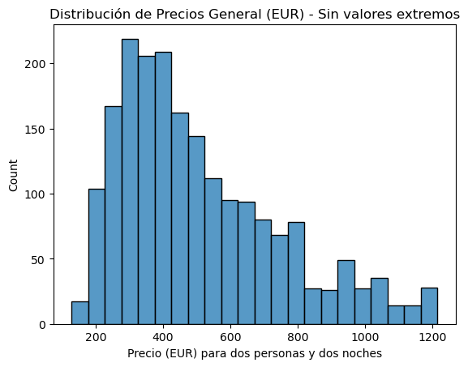

```python
sns.histplot(data=amsterdam_superhost_IQR, x='realSum')

plt.title('Distribución de Precios General (EUR) - Sin valores extremos')
plt.xlabel('Precio (EUR) para dos personas y dos noches')
plt.ylabel('Count')

plt.show()
```

### 4.2 Creación de histograma de Precios (EUR) para Amsterdam dependiendo si el oferente es Super Host

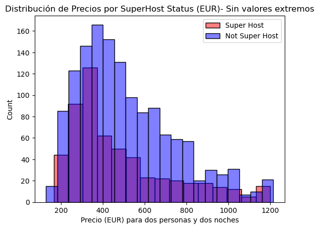

```python
superhost_yes_IQR = amsterdam_superhost_IQR[amsterdam_superhost_IQR['host_is_superhost'] == True]
superhost_no_IQR = amsterdam_superhost_IQR[amsterdam_superhost_IQR['host_is_superhost'] == False]

sns.histplot(data=superhost_yes_IQR, x='realSum', kde=False, color='red', alpha=0.5)
sns.histplot(data=superhost_no_IQR, x='realSum', kde=False, color='blue', alpha=0.5)

plt.legend(labels=['Super Host', 'Not Super Host'])

plt.title('Distribución de Precios por SuperHost Status (EUR)- Sin valores extremos')
plt.xlabel('Precio (EUR) para dos personas y dos noches')
plt.ylabel('Count')

plt.show()
```

### 4.3 Creación de diagrama de caja de Precios (EUR) separados por estatus de SuperHost

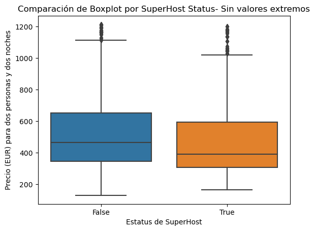

```python
sns.boxplot(data=amsterdam_superhost_IQR, x='host_is_superhost', y='realSum')

plt.title('Comparación de Boxplot por SuperHost Status - Sin valores extremos')
plt.xlabel('Estatus de SuperHost')
plt.ylabel('Precio (EUR) para dos personas y dos noches')

plt.show()
```

# 5. Prueba de normalidad

En los gráficos anteriores se puede apreciar que existe una diferencia de precios entre los grupos, por lo que vale la pena preguntarse si esa diferencia es estadísticamente significativa.

Antes de saltar a cualquier prueba de hipótesis, es responsable primero comprobar la normalidad de las variables para decidir si se usará una prueba basada en la media (sensible a datos extremos) o en la mediana (no sensible a datos extremos)

### 5.1 Importación de normaltest para realizar la prueba

```python
from scipy.stats import normaltest
```

### 5.2 Planteo de hipóstesis

```python
# Hipótesis nula
H0 = "Los datos están distribuidos normalmente"

# Hipótesis alternativa
HA = "Los datos no están distribuidos normalmente"
```

### 5.3 Realización de la prueba

```python
# Se obstienen el estadístico y el p valor de la prueba
stat, p = normaltest(amsterdam_superhost_IQR['realSum'])

print("Estadístico:", stat)
print("p valor:", p)
```

```
Estadístico: 218.26276978763326
p valor: 4.025703063980281e-48
```

### 5.4 Conclusión de la prueba

```python
# Comprobación si el p valor está bajo el alfa de 5%
if p < 0.05:
    print("Se puede rechazar la hipótesis nula.", HA)
else:
    print("No se puede rechazar la hipótesis nula.", H0)
```

```
Se puede rechazar la hipótesis nula. Los datos no están distribuidos normalmente
```

# 6. Prueba de diferencia de medianas: U de Mann Whitney

Como los datos no tienen una distribución normal, se usará una prueba de diferencia estadística basada en la mediana y el rango : La U de Mann Whitney

### 6.1 Importación de mannwhitneyu para la prueba y numpy para el cálculo de la mediana

```python
from scipy.stats import mannwhitneyu
import numpy as np
```

### 6.2 Preparación de los datos

```python
# Se toman los dataframes previamente creados por estado de superhost y se transforman a lista
superhost_yes_IQR_list = superhost_yes_IQR['realSum'].tolist()
superhost_no_IQR_list = superhost_no_IQR['realSum'].tolist()

# Se convierten los objetos de las listas a 'float' para que puedan usarse en la prueba
superhost_yes_IQR_list = [float(i) for i in superhost_yes_IQR_list]
superhost_no_IQR_list = [float(i) for i in superhost_no_IQR_list]
```

### 6.3 Cálculo de las medianas

```python
# Calculo de la mediana redondeada para cada grupo
median_superhost = np.round(np.median(superhost_yes_IQR_list), 2)
median_not_superhost = np.round(np.median(superhost_no_IQR_list), 2)

#Impresión de la mediana
print("La mediana de precio para habitaciones ofrecidas por usuarios que son super hosts es:",
      median_superhost, "EUR")
print("La mediana de precio para habitaciones ofrecidas por usuarios que no son super hosts es:",
      median_not_superhost, "EUR")
```

```
La mediana de precio para habitaciones ofrecidas por usuarios que son super hosts es: 390.65 EUR
La mediana de precio para habitaciones ofrecidas por usuarios que no son super hosts es: 464.58 EUR
```

### 6.4 Planteo de hipóstesis

```python
# Hipótesis nula
H0 = "La diferencia entre los dos grupos NO es estadísticamente significativa"

# Hipótesis alternativa
HA = "La diferencia entre los dos grupos es estadísticamente significativa"
```

### 6.5 Realización de la prueba

```python
U, p = mannwhitneyu(superhost_yes_IQR_list, superhost_no_IQR_list, alternative='two-sided')

print("Estadístico U:", U)
print("p valor", p)
```

```
Estadístico U: 348232.5
p valor 1.6759278734907537e-05
```

### 6.6 Conclusión de la prueba

```python
# Comprobación si el p valor está bajo el alfa de 5%
if p < 0.05:
    print("Se puede rechazar la hipótesis nula.", HA)
else:
    print("No se puede rechazar la hipótesis nula.", H0)
```

```
Se puede rechazar la hipótesis nula. La diferencia entre los dos grupos es estadísticamente significativa
```

# Conclusión

Contrario a la hipóstesis planteada al principio, se demostró que los precios ofrecidos por los Superhost son por lo general más bajos que los ofrecidos por el resto de usuarios. En particular, la diferencia entre ambas medianas es de 75 euros, lo que significa un 16% menos en la mediana de precios de los superhost.

Ello puede deberse a que precios más bajos dejan más contentos a los clientes, lo que facilita a los oferentes obtener el estatus de superhost. El orden causal se invierte respecto a la hipótesis inicial. En lugar de:

> Estatus de Superhost --> Precios más altos

es:

> Precios más bajos --> Estatus de Superhost

Finalmente, se puede destacar la importancia de utilizar la prueba correcta según la distribución de los datos, puesto que, en un caso donde los datos tengan una distribución orgánicamente sesgada y con tantos valores extremos (como suele pasar en mercados con sectores de lujo), el análisis de las medias no hará más que confundir y entregar resultados disparatados.